# Lab 3 — clustering

```python
import json
import matplotlib.pyplot as plt
import numpy as np
import pickle
import sklearn.cluster
import random
from bokeh.io import show, output_notebook
from bokeh.layouts import gridplot
from bokeh.plotting import figure, ColumnDataSource
from bokeh.models import HoverTool, ResetTool, PanTool, WheelZoomTool, SaveTool
from bokeh.palettes import Category10
from matplotlib.colors import rgb2hex
from operator import itemgetter
output_notebook()

%matplotlib inline
plt.style.use("ggplot")
```

## Exercise 3.11:

```python
with open("tag2score.pickle", "rb") as f:
    tag2score = pickle.load(f)
```

```python
low_dim_values = [tag2score[i] for i in tag2score.keys()]
```

```python
def display_clustering_preview(nb_clusters):

    kmeans = sklearn.cluster.KMeans(n_clusters=nb_clusters).fit(low_dim_values)
    predictions = kmeans.predict(low_dim_values)

    axes_names = ["dim0", "dim1", "dim2", "dim3", "dim4"]
    source = ColumnDataSource(
        data={
            "dim0": [x[0] for x in low_dim_values],
            "dim1": [x[1] for x in low_dim_values],
            "dim2": [x[2] for x in low_dim_values],
            "dim3": [x[3] for x in low_dim_values],
            "dim4": [x[4] for x in low_dim_values],
            "closest_cluster": [x for x in predictions],
            "tag": [x for x in tag2score.keys()],
            "color": [Category10[10][x] for x in predictions],
        })

    hover = HoverTool(
        tooltips=[
            ("tag", "@tag")
        ])

    tools = [hover, ResetTool(), PanTool(), WheelZoomTool(), SaveTool()]

    plots = []

    for y in range(5):
        plot_line = []
        for x in range(5):
            if(y <= x): plot_line.append(None)
            else:
                p = figure(plot_width=350, plot_height=350, tools=tools, title= "Direction {} w.r.t. direction {} with {} clusters".format(x+1, y+1, nb_clusters))
                p.circle(axes_names[x], axes_names[y], source=source, size=5, alpha=0.5, color="color")
                plot_line.append(p)
        if(y != 0):
            plots.append(plot_line)

    grid = gridplot(plots)
    show(grid, notebook_handle=True)
```

```python
display_clustering_preview(2)
```

[interactive chart not shown]

As we can see in the plots above, for two clusters, the direction 5 (which contrasts suspense and commedy) separates the clusters very cleanly with respect to every other direction.

```python
display_clustering_preview(3)
```

[interactive chart not shown]

Here again, the direction 5 separates the three clusters cleanly when plotted against directions 2 (romance vs action) and 4 (CGI vs thriller)

```python
display_clustering_preview(4)
```

[interactive chart not shown]

Once again, direction 5 separates the four clusters in a clean fashion with respect to every other direction.

```python
display_clustering_preview(5)
```

[interactive chart not shown]

In this final plot, direction 5 separates the clusters again, especially when plotted against directions 1 and 2.

In general, we notice direction 5 and 2 separate the clusters the best.

## Exercise 3.12

```python
data = sc.textFile("/ix/ml-20m/movies.txt").map(json.loads)
id2genres = dict(data.map(itemgetter("movieId", "genres")).collect())
keys = dict(id2genres).keys()
for key in keys:
    if id2genres[key][0] == "(no genres listed)":
        del id2genres[key]
```

```python
with open("most-rated.pickle", "rb") as f:
    most_rated = pickle.load(f)
```

```python
def k_medioids(points, distance_function, nb_clusters):
    current_medioids = np.array([-1] * nb_clusters)
    new_medioids = np.array([points[random.randint(0, len(points))] for _ in range(nb_clusters)])

    while not ((new_medioids == current_medioids).all()):

        current_medioids[:] = new_medioids[:]
        new_medioids = np.array([-1] * nb_clusters)

        #Initialize empty clusters
        clusters = []
        for cluster in range(nb_clusters):
            clusters.append([])

        #Assign each point to its cluster
        for point in points:
            point_distances = []
            for medioid_index in range(nb_clusters):
                point_distances.append(distance_function(point, current_medioids[medioid_index]))
            clusters[np.argmin(point_distances)].append(point)

        for medioid_index in range(nb_clusters):
            costs = []
            for candidate in clusters[medioid_index]:
                total_cost = 0
                for point in clusters[medioid_index]:
                    total_cost += distance_function(candidate, point)
                costs.append(total_cost)
            new_medioids[medioid_index] = clusters[medioid_index][np.argmin(costs)]

    return new_medioids, clusters
```

```python
def dist(a, b):
    x = id2genres[a]
    y = id2genres[b]
    inter = []
    union = x[:]
    for elm1 in y:
        for elm2 in x:
            if elm1 == elm2:
                inter.append(elm1)
    for elm in y:
        if not elm in union:
            union.append(elm)
    return 1 - len(inter)/len(union)
```

```python
data = []
for movie in most_rated:
    data.append(movie[0])
```

```python
def compute_genre_freq(clusters):
    genre_freqs = []
    genres = []
    for cluster in clusters:
        for movie in cluster:
            for genre in id2genres[movie]:
                if genre not in genres:
                    genres.append(genre)
    for cluster in clusters:
        freqs = {}
        for movie in cluster:
            for genre in genres:
                if genre in id2genres[movie]:
                    if genre in freqs.keys():
                        freqs[genre] += 1
                    else:
                        freqs[genre] = 0
                elif genre not in freqs.keys():
                    freqs[genre] = 0
        genre_freqs.append(freqs)
    return genre_freqs
```

```python
def display_genre_freq(genre_freqs):
    genres = list(genre_freqs[0].keys())
    cluster0_freqs = list(genre_freqs[0].values())
    cluster1_freqs = list(genre_freqs[1].values())

    agg = [cluster0_freqs[i] + cluster1_freqs[i] for i in range(len(genres))]
    idx = np.argsort(agg)
    genres, cluster0_freqs, cluster1_freqs = [np.take(x, idx) for x in [genres, cluster0_freqs, cluster1_freqs]]

    y = np.arange(len(genres))

    fig, axes = plt.subplots(ncols=2, sharey=True)
    axes[0].barh(y, cluster0_freqs, align='center', color='blue', zorder=10)
    axes[0].set(title='Occurences in cluster 1')
    axes[1].barh(y, cluster1_freqs, align='center', color='red', zorder=10)
    axes[1].set(title='Occurences in cluster 2')

    axes[0].invert_xaxis()
    axes[0].set(yticks=y, yticklabels=genres)
    axes[0].yaxis.tick_right()

    for ax in axes.flat:
        ax.margins(0.03)
        ax.grid(True)

    fig.tight_layout()
    fig.subplots_adjust(wspace=0.5)
    plt.show()
```

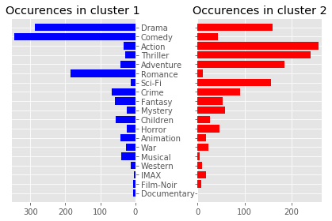

```python
medioids, clusters = k_medioids(data, dist, 2)
genre_freqs = compute_genre_freq(clusters)
display_genre_freq(genre_freqs)
```

As we can see from the plot above, the first cluster contains most of the movies with the genre Comedy and Romance, while the second cluster contains movies with the genres Action, Thriller, Adventure and Sci-Fi. The genre Drama, which is the most common genre in the dataset, is split between the two clusters with around two thirds of occurences in cluster 1.

If we look back at the principal component analysis we did in the previous part, we found that the two directions that split the clusters the best were directions 5 (Suspense vs Comedy) and direction 2 (Romance vs Action). Here this is the case again, with cluster 1 having the Comedy and Romance movies while cluster 2 contains the Suspense and Action movies.